# Linear Regressions

Michael Barrows

2018-10-24

## Agenda

- Terminology
- Model Building Process
- Simple Linear Regression
- Multiple Regression

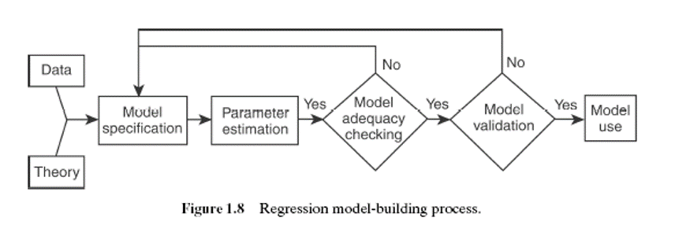

# 1. Terminology

## Residuals

The difference ( $\Delta$) between observed value ($y_x$) and estimated value $\hat{y}$

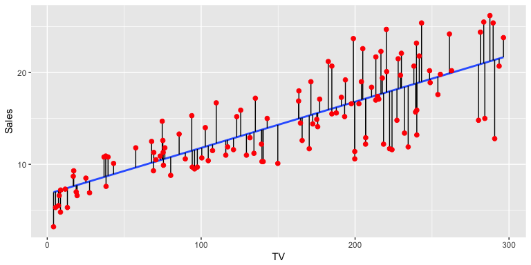

## Standard Error

- The “wiggle room” around the population mean $(\bar{x},\bar{y})$ of your regression line
- This “wiggle” is a normal distribution at the extreme X values
- Lower is better

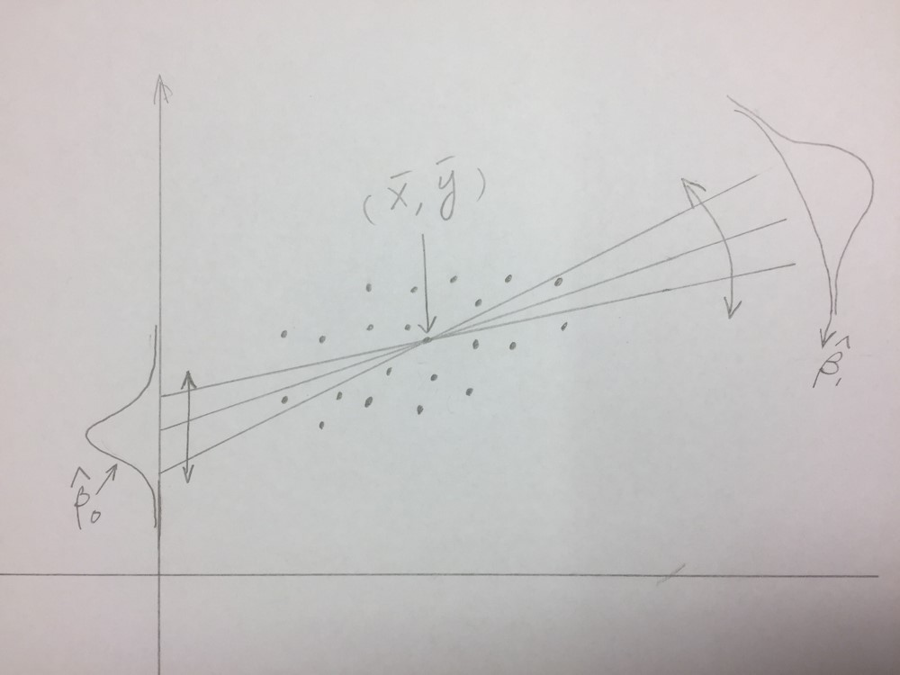

## R^2 and Adj. R^2

- The “fit” of your regression equation
- How tightly are observed values $(y_i,x_i)$ clustered around your estimated values $(\hat{x}_i,\hat{y}_i)$
- 0 < x < 1
- Higher is better

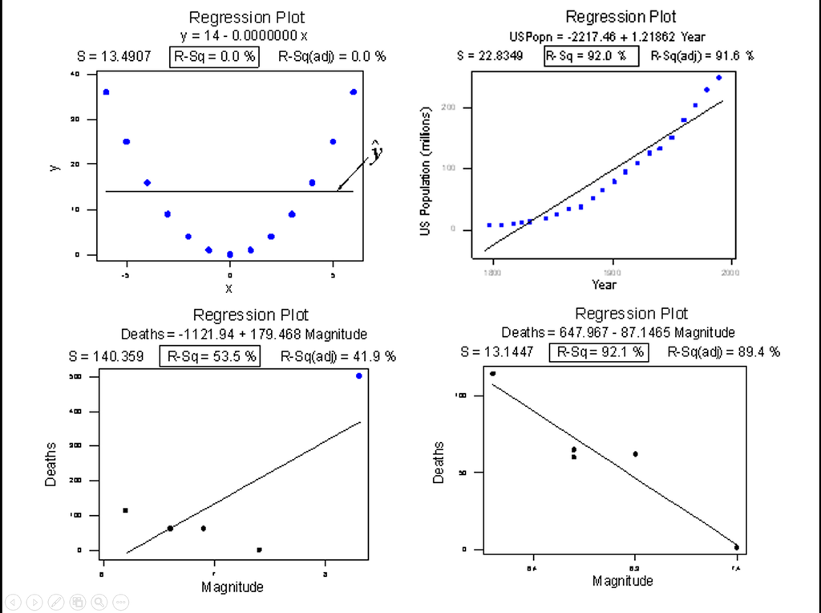

## Confidence Interval

- The lower and upper bounds of your $\hat{y}$ value given a particular $\alpha$-value
- Typically, $\alpha = 0.95$

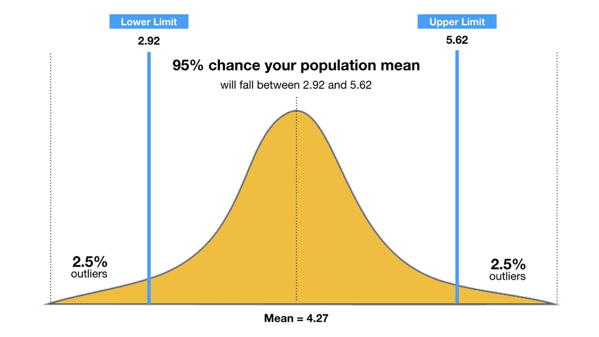

## p-value

- probability of experiencing the observed results assuming the Null Hypothesis $H_0$ is held true
- Probability that any difference observed is significant
- Value between 0 and 1
- Lower is “better”
- $1 - \alpha =$ upper $p$ limit

## Transformation

- Mathematical operations done to linearize a regression
- Ex:
  - Sqrt()
  - ln()
  - (1/sqrt())
  - and more
- Can determine with lambda from Box-Cox

## Multicollinearity

- When the inclusion of one variable influences another and visa versa
- This is detrimental to a good regression equation
- Solved by removing one or another variable
- Can test with Variance Inflation Factor (VIF function) in R

# 2. Modeling Process/Simple Linear Regression

We will use the `airquality’ dataset for the remainder of this presentation. This is found in the ‘datasets’ package. Install it if necessary and load it with the code below:

```r
require(datasets)
```

## Data Examination

Before you start modeling it is important to explore your data from a high level

- Structure
- Summary statistics
- Figures

## Structure

```r
str(airquality)
```

```
## 'data.frame':    153 obs. of  6 variables:
##  $ Ozone  : int  41 36 12 18 NA 28 23 19 8 NA ...
##  $ Solar.R: int  190 118 149 313 NA NA 299 99 19 194 ...
##  $ Wind   : num  7.4 8 12.6 11.5 14.3 14.9 8.6 13.8 20.1 8.6 ...
##  $ Temp   : int  67 72 74 62 56 66 65 59 61 69 ...
##  $ Month  : int  5 5 5 5 5 5 5 5 5 5 ...
##  $ Day    : int  1 2 3 4 5 6 7 8 9 10 ...
```

## Summary Statistics

```r
summary(airquality)
```

```
##      Ozone           Solar.R           Wind             Temp
##  Min.   :  1.00   Min.   :  7.0   Min.   : 1.700   Min.   :56.00
##  1st Qu.: 18.00   1st Qu.:115.8   1st Qu.: 7.400   1st Qu.:72.00
##  Median : 31.50   Median :205.0   Median : 9.700   Median :79.00
##  Mean   : 42.13   Mean   :185.9   Mean   : 9.958   Mean   :77.88
##  3rd Qu.: 63.25   3rd Qu.:258.8   3rd Qu.:11.500   3rd Qu.:85.00
##  Max.   :168.00   Max.   :334.0   Max.   :20.700   Max.   :97.00
##  NA's   :37       NA's   :7
##      Month            Day
##  Min.   :5.000   Min.   : 1.0
##  1st Qu.:6.000   1st Qu.: 8.0
##  Median :7.000   Median :16.0
##  Mean   :6.993   Mean   :15.8
##  3rd Qu.:8.000   3rd Qu.:23.0
##  Max.   :9.000   Max.   :31.0
##
```

## Figures

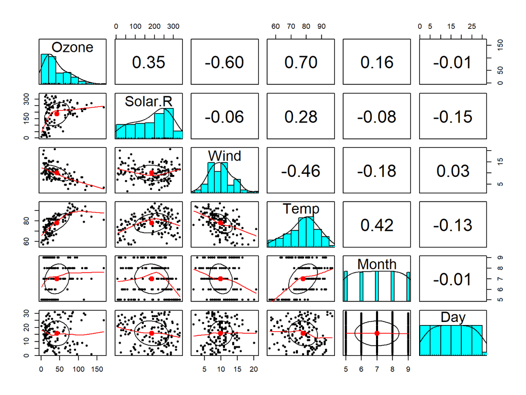

## Model Beginnings

- Start with your hypothesised model
- This is usually either the simplest or most complicated model
- Simplest model is generally: $y = B_0 + B_1x$
- “Most” complicated is generally: $y = B_0 + B_1x_1 + B_2x_2 + B_nx_n$

## Psudo Models

- Salary ~ HoursWorked
- Salary ~ HoursWorked + Experience + Infractions + age
- Ozone ~ Temp + Wind + Solar.R + Month + Day

## Coefficient Analysis

Let’s start building a model for the airquality data.

Start with a simple model (ozone as response variable):

```r
model1 <- lm(Ozone ~ Temp, data = airquality)
```

View the summary:

```r
summary(model1)
```

```
##
## Call:
## lm(formula = Ozone ~ Temp, data = airquality)
##
## Residuals:
##     Min      1Q  Median      3Q     Max
## -40.729 -17.409  -0.587  11.306 118.271
##
## Coefficients:
##              Estimate Std. Error t value Pr(>|t|)
## (Intercept) -146.9955    18.2872  -8.038 9.37e-13 ***
## Temp           2.4287     0.2331  10.418  < 2e-16 ***
## ---
## Signif. codes:  0 '***' 0.001 '**' 0.01 '*' 0.05 '.' 0.1 ' ' 1
##
## Residual standard error: 23.71 on 114 degrees of freedom
##   (37 observations deleted due to missingness)
## Multiple R-squared:  0.4877, Adjusted R-squared:  0.4832
## F-statistic: 108.5 on 1 and 114 DF,  p-value: < 2.2e-16
```

## Key values

Coefficients

- Slope ($\beta_1$)
- Intercept ($\beta_0$)

Goodness of fit

- p-value
- Adj R-squared

## Residual Analysis

- Help to get an idea of goodness of fit
- May suggest a possible transformation
- Help to spot outliers

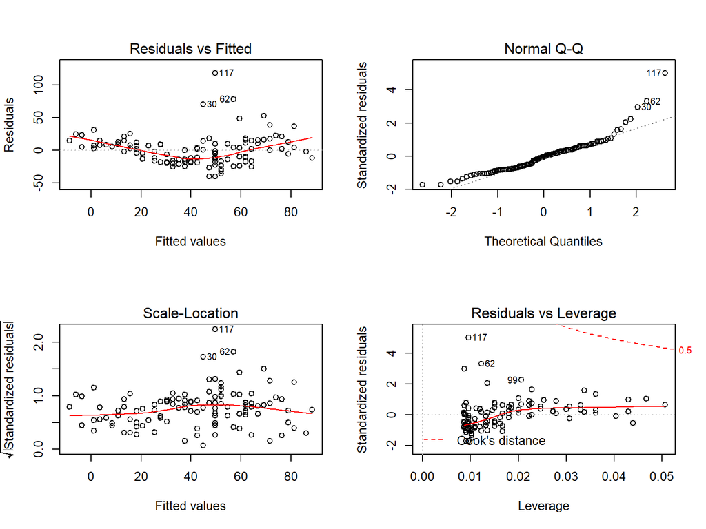

```r
par(mfrow = c(2,2))
plot(model1)
```

## Transformation

- [Use the QQ plot](https://stats.stackexchange.com/questions/101274/how-to-interpret-a-qq-plot) (skewness) as well as the [Fitted v. Residuals plot](http://docs.statwing.com/interpreting-residual-plots-to-improve-your-regression/) (normalcy) to determine possible transformations
- Can also use Box-Cox test
  - More exact but not as easy to explain

```r
model3 <- lm(log(Ozone) ~ log(Temp), data = airquality)
summary(model3)
```

```
##
## Call:
## lm(formula = log(Ozone) ~ log(Temp), data = airquality)
##
## Residuals:
##      Min       1Q   Median       3Q      Max
## -2.05461 -0.35165  0.05216  0.36246  1.46775
##
## Coefficients:
##             Estimate Std. Error t value Pr(>|t|)
## (Intercept) -18.5525     1.9148  -9.689   <2e-16 ***
## log(Temp)     5.0538     0.4403  11.479   <2e-16 ***
## ---
## Signif. codes:  0 '***' 0.001 '**' 0.01 '*' 0.05 '.' 0.1 ' ' 1
##
## Residual standard error: 0.592 on 114 degrees of freedom
##   (37 observations deleted due to missingness)
## Multiple R-squared:  0.5362, Adjusted R-squared:  0.5321
## F-statistic: 131.8 on 1 and 114 DF,  p-value: < 2.2e-16
```

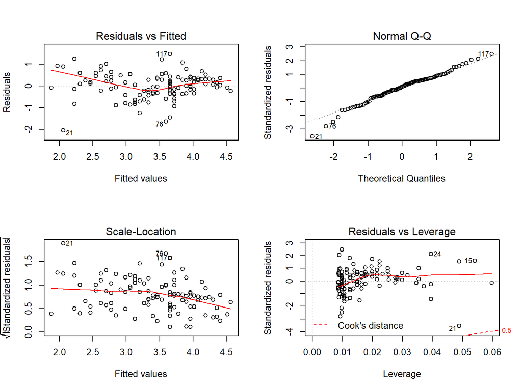

```r
par(mfrow = c(2,2))
plot(model3)
```

Is this worth the transformation?

Is the original model that bad?

## Validation

- **Train** your model on a subset of data (70%)
- **Test** your model on another subset (20%)
- **Validate** your model on yet another subset (10%)

This method is good for ensuring the accuracy and predictive strength of your model

# 3. Multivariate Linear Regression (Full Example)

## Data

Wine Quality: A classic example

```r
require(data.table)
wine <- fread("../Data/winequality-red.csv")
```

## Summary Stats and Visual Assesment

```r
str(wine)
```

```
## Classes 'data.table' and 'data.frame':   1599 obs. of  12 variables:
##  $ fixed acidity       : num  7.4 7.8 7.8 11.2 7.4 7.4 7.9 7.3 7.8 7.5 ...
##  $ volatile acidity    : num  0.7 0.88 0.76 0.28 0.7 0.66 0.6 0.65 0.58 0.5 ...
##  $ citric acid         : num  0 0 0.04 0.56 0 0 0.06 0 0.02 0.36 ...
##  $ residual sugar      : num  1.9 2.6 2.3 1.9 1.9 1.8 1.6 1.2 2 6.1 ...
##  $ chlorides           : num  0.076 0.098 0.092 0.075 0.076 0.075 0.069 0.065 0.073 0.071 ...
##  $ free sulfur dioxide : num  11 25 15 17 11 13 15 15 9 17 ...
##  $ total sulfur dioxide: num  34 67 54 60 34 40 59 21 18 102 ...
##  $ density             : num  0.998 0.997 0.997 0.998 0.998 ...
##  $ pH                  : num  3.51 3.2 3.26 3.16 3.51 3.51 3.3 3.39 3.36 3.35 ...
##  $ sulphates           : num  0.56 0.68 0.65 0.58 0.56 0.56 0.46 0.47 0.57 0.8 ...
##  $ alcohol             : num  9.4 9.8 9.8 9.8 9.4 9.4 9.4 10 9.5 10.5 ...
##  $ quality             : int  5 5 5 6 5 5 5 7 7 5 ...
##  - attr(*, ".internal.selfref")=<externalptr>
```

```r
summary(wine)
```

```
##  fixed acidity   volatile acidity  citric acid    residual sugar
##  Min.   : 4.60   Min.   :0.1200   Min.   :0.000   Min.   : 0.900
##  1st Qu.: 7.10   1st Qu.:0.3900   1st Qu.:0.090   1st Qu.: 1.900
##  Median : 7.90   Median :0.5200   Median :0.260   Median : 2.200
##  Mean   : 8.32   Mean   :0.5278   Mean   :0.271   Mean   : 2.539
##  3rd Qu.: 9.20   3rd Qu.:0.6400   3rd Qu.:0.420   3rd Qu.: 2.600
##  Max.   :15.90   Max.   :1.5800   Max.   :1.000   Max.   :15.500
##    chlorides       free sulfur dioxide total sulfur dioxide
##  Min.   :0.01200   Min.   : 1.00       Min.   :  6.00
##  1st Qu.:0.07000   1st Qu.: 7.00       1st Qu.: 22.00
##  Median :0.07900   Median :14.00       Median : 38.00
##  Mean   :0.08747   Mean   :15.87       Mean   : 46.47
##  3rd Qu.:0.09000   3rd Qu.:21.00       3rd Qu.: 62.00
##  Max.   :0.61100   Max.   :72.00       Max.   :289.00
##     density             pH          sulphates         alcohol
##  Min.   :0.9901   Min.   :2.740   Min.   :0.3300   Min.   : 8.40
##  1st Qu.:0.9956   1st Qu.:3.210   1st Qu.:0.5500   1st Qu.: 9.50
##  Median :0.9968   Median :3.310   Median :0.6200   Median :10.20
##  Mean   :0.9967   Mean   :3.311   Mean   :0.6581   Mean   :10.42
##  3rd Qu.:0.9978   3rd Qu.:3.400   3rd Qu.:0.7300   3rd Qu.:11.10
##  Max.   :1.0037   Max.   :4.010   Max.   :2.0000   Max.   :14.90
##     quality
##  Min.   :3.000
##  1st Qu.:5.000
##  Median :6.000
##  Mean   :5.636
##  3rd Qu.:6.000
##  Max.   :8.000
```

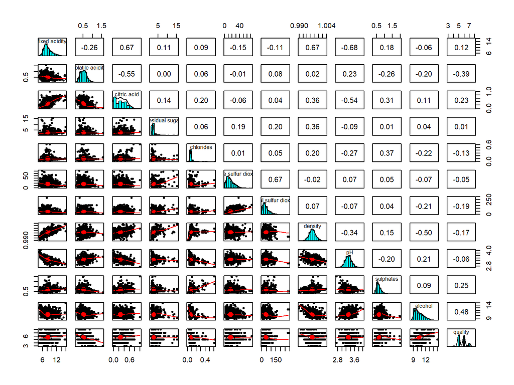

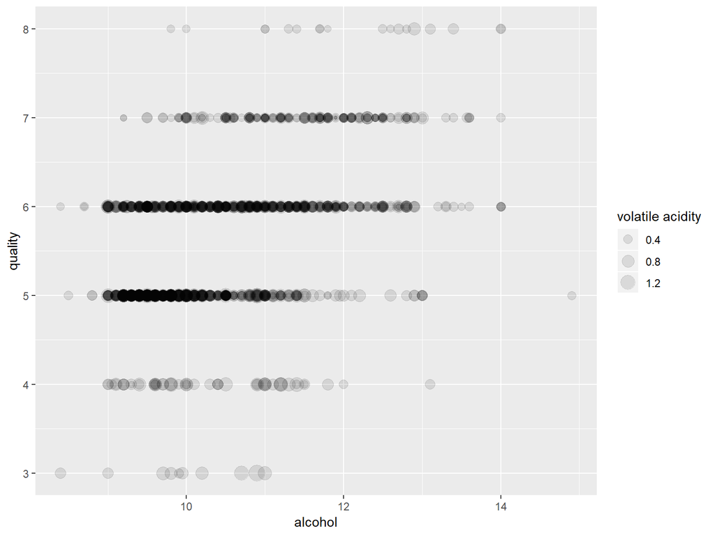

```r
require(ggplot2)
ggplot(wine, aes(alcohol,quality))+
  geom_point(aes(
    size = `volatile acidity`)
    , alpha = 0.1)
```

## Beginning Model

```r
model1 <- lm(quality~. , data = wine)
summary(model1)
```

```
##
## Call:
## lm(formula = quality ~ ., data = wine)
##
## Residuals:
##      Min       1Q   Median       3Q      Max
## -2.68911 -0.36652 -0.04699  0.45202  2.02498
##
## Coefficients:
##                          Estimate Std. Error t value Pr(>|t|)
## (Intercept)             2.197e+01  2.119e+01   1.036   0.3002
## `fixed acidity`         2.499e-02  2.595e-02   0.963   0.3357
## `volatile acidity`     -1.084e+00  1.211e-01  -8.948  < 2e-16 ***
## `citric acid`          -1.826e-01  1.472e-01  -1.240   0.2150
## `residual sugar`        1.633e-02  1.500e-02   1.089   0.2765
## chlorides              -1.874e+00  4.193e-01  -4.470 8.37e-06 ***
## `free sulfur dioxide`   4.361e-03  2.171e-03   2.009   0.0447 *
## `total sulfur dioxide` -3.265e-03  7.287e-04  -4.480 8.00e-06 ***
## density                -1.788e+01  2.163e+01  -0.827   0.4086
## pH                     -4.137e-01  1.916e-01  -2.159   0.0310 *
## sulphates               9.163e-01  1.143e-01   8.014 2.13e-15 ***
## alcohol                 2.762e-01  2.648e-02  10.429  < 2e-16 ***
## ---
## Signif. codes:  0 '***' 0.001 '**' 0.01 '*' 0.05 '.' 0.1 ' ' 1
##
## Residual standard error: 0.648 on 1587 degrees of freedom
## Multiple R-squared:  0.3606, Adjusted R-squared:  0.3561
## F-statistic: 81.35 on 11 and 1587 DF,  p-value: < 2.2e-16
```

## Variable Pruning

Multicolinearity?

```r
require(car)
vif(model1)
```

```
##        `fixed acidity`     `volatile acidity`          `citric acid`
##               7.767512               1.789390               3.128022
##       `residual sugar`              chlorides  `free sulfur dioxide`
##               1.702588               1.481932               1.963019
## `total sulfur dioxide`                density                     pH
##               2.186813               6.343760               3.329732
##              sulphates                alcohol
##               1.429434               3.031160
```

## Stepwise Variable Selection

```r
sm1 <- step(model1,direction = 'backward')
```

```r
sm1
```

```
##
## Call:
## lm(formula = quality ~ `volatile acidity` + chlorides + `free sulfur dioxide` +
##     `total sulfur dioxide` + pH + sulphates + alcohol, data = wine)
##
## Coefficients:
##            (Intercept)      `volatile acidity`               chlorides
##               4.430099               -1.012753               -2.017814
##  `free sulfur dioxide`  `total sulfur dioxide`                      pH
##               0.005077               -0.003482               -0.482661
##              sulphates                 alcohol
##               0.882665                0.289303
```

```r
minModel <- lm(quality~1, data = wine)
maxModel <- formula(lm(quality~., data = wine))
sm2 <- step(minModel, direction = 'forward', scope = maxModel)
```

```r
sm2
```

```
##
## Call:
## lm(formula = quality ~ alcohol + `volatile acidity` + sulphates +
##     `total sulfur dioxide` + chlorides + pH + `free sulfur dioxide`,
##     data = wine)
##
## Coefficients:
##            (Intercept)                 alcohol      `volatile acidity`
##               4.430099                0.289303               -1.012753
##              sulphates  `total sulfur dioxide`               chlorides
##               0.882665               -0.003482               -2.017814
##                     pH   `free sulfur dioxide`
##              -0.482661                0.005077
```

## Test Model Selection Results

```r
model2 <- lm(formula = quality ~ `volatile acidity` + chlorides + `free sulfur dioxide` +
    `total sulfur dioxide` + pH + sulphates + alcohol, data = wine)
summary(model2)
```

```
##
## Call:
## lm(formula = quality ~ `volatile acidity` + chlorides + `free sulfur dioxide` +
##     `total sulfur dioxide` + pH + sulphates + alcohol, data = wine)
##
## Residuals:
##      Min       1Q   Median       3Q      Max
## -2.68918 -0.36757 -0.04653  0.46081  2.02954
##
## Coefficients:
##                          Estimate Std. Error t value Pr(>|t|)
## (Intercept)             4.4300987  0.4029168  10.995  < 2e-16 ***
## `volatile acidity`     -1.0127527  0.1008429 -10.043  < 2e-16 ***
## chlorides              -2.0178138  0.3975417  -5.076 4.31e-07 ***
## `free sulfur dioxide`   0.0050774  0.0021255   2.389    0.017 *
## `total sulfur dioxide` -0.0034822  0.0006868  -5.070 4.43e-07 ***
## pH                     -0.4826614  0.1175581  -4.106 4.23e-05 ***
## sulphates               0.8826651  0.1099084   8.031 1.86e-15 ***
## alcohol                 0.2893028  0.0167958  17.225  < 2e-16 ***
## ---
## Signif. codes:  0 '***' 0.001 '**' 0.01 '*' 0.05 '.' 0.1 ' ' 1
##
## Residual standard error: 0.6477 on 1591 degrees of freedom
## Multiple R-squared:  0.3595, Adjusted R-squared:  0.3567
## F-statistic: 127.6 on 7 and 1591 DF,  p-value: < 2.2e-16
```

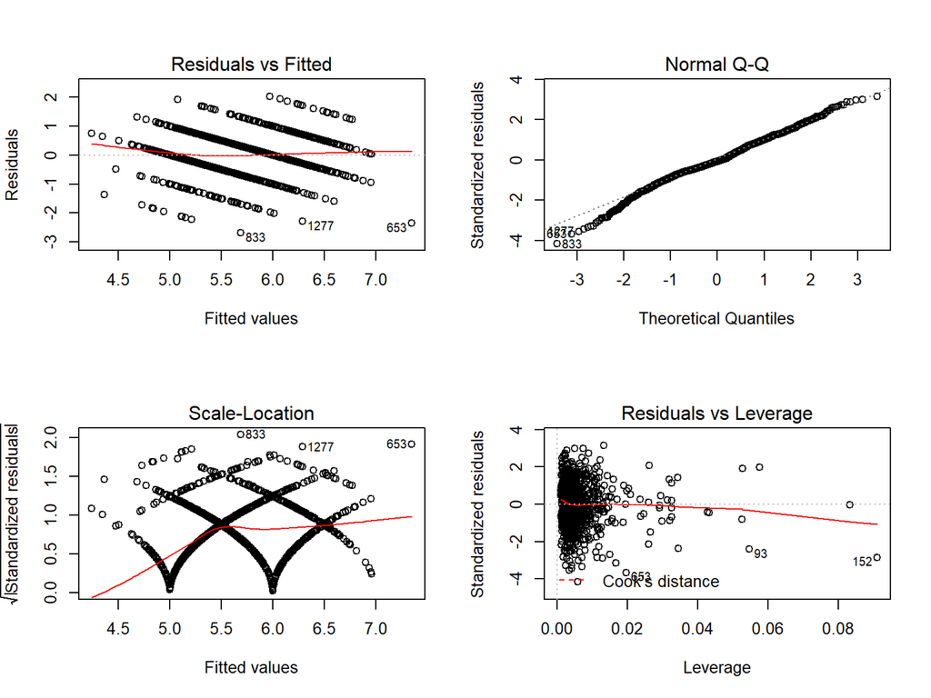

```r
par(mfrow = c(2,2))
plot(model2)
```